# Lesson2_Practice

##Plotting the group means

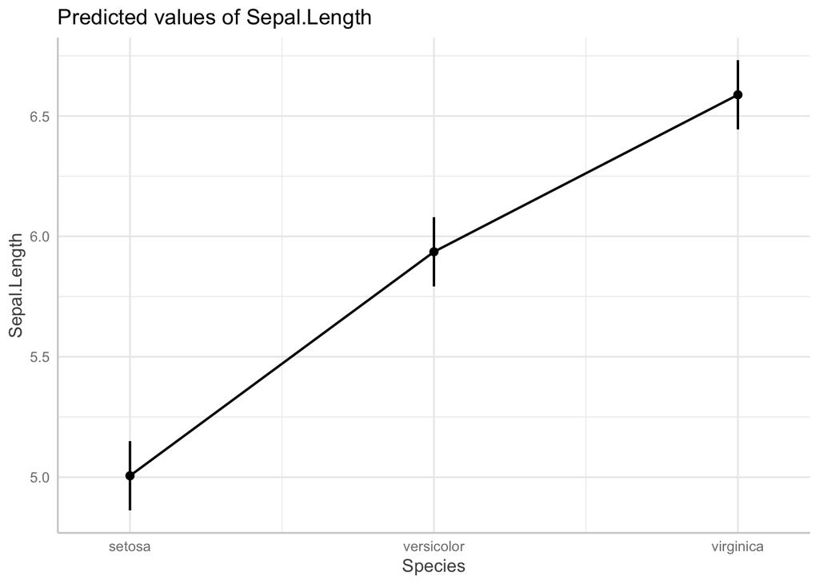

```r
plot(gge, connect.lines = TRUE)
```

##The effect size

```r
library(effectsize)
eta_squared(anova_result)
```

```
## For one-way between subjects designs, partial eta squared is equivalent
##   to eta squared. Returning eta squared.
```

```
## # Effect Size for ANOVA
##
## Parameter | Eta2 |       95% CI
## -------------------------------
## Species   | 0.62 | [0.54, 1.00]
##
## - One-sided CIs: upper bound fixed at [1.00].
```

##Post-hoc Test Holm:

```r
ptt <- pairwise.t.test(x = iris$Sepal.Length, g = iris$Species)
model_parameters(ptt)
```

```
## # Fixed Effects
##
## Group1     |     Group2 |      p
## --------------------------------
## versicolor |     setosa | < .001
## virginica  |     setosa | < .001
## virginica  | versicolor | < .001
##
## p-value adjustment method: Holm (1979)
```

*Interpret*: Post hoc tests (using the Holm correction to adjust p) indicated that all groups are diffent in Sepal.Length.

###Post-hoc Test using Bonferroni:

```r
ptt1 <- pairwise.t.test(x = iris$Sepal.Length, g = iris$Species,
                       p.adjust.method = "bonferroni")
model_parameters(ptt1)
```

```
## # Fixed Effects
##
## Group1     |     Group2 |      p
## --------------------------------
## versicolor |     setosa | < .001
## virginica  |     setosa | < .001
## virginica  | versicolor | < .001
##
## p-value adjustment method: Bonferroni
```

#TEXT MINING #loading the packages

```r
library(dplyr)
library(tidytext)
library(tidyr)
```

#import data

```r
data_gov <- read_csv("data_gov.csv")
data_gov
```

```
## # A tibble: 200 × 3
##         id username        tweet
##      <dbl> <chr>           <chr>
##  1 1.33e18 govlarryhogan   "COVID-19 has returned to our state in a big way, an…
##  2 1.34e18 nygovcuomo      "Delivering an update on the state's COVID-19 respon…
##  3 1.25e18 govmlg          "Stay home unless it is absolutely essential. Act as…
##  4 1.24e18 gavinnewsom     "Families should not lose their homes because of COV…
##  5 1.3 e18 dougburgum      "The highly skilled team at the @NDDOH State Lab is …
##  6 1.3 e18 govevers        "Wisconsin workers continue to face financial burden…
##  7 1.28e18 governortomwolf "🔹 Social distancing, masking, and other safety mea…
##  8 1.24e18 govraimondo     "Students: Please take this seriously. You need to k…
##  9 1.3 e18 govmikedewine   "Some reopening requirements include:   ✅Limited ca…
## 10 1.29e18 governortomwolf "I want to talk about the transphobic incident invol…
## # ℹ 190 more rows
```

- Using `unnest_tokens` to put each word in a row. - Often in text analysis, we will want to remove stop words, which are We can remove stop words words that are not useful for an analysis, typically extremely common words such as “the,” “of,” “to,” and so forth in English. We can remove stop words (kept in the tidy‐text dataset stop_words) with an `anti_join()`.

#count the number of tweets by username

```r
tweet_counts <- data_gov %>%
  group_by(username) %>%
  summarize(tweet_count = n())
tweet_counts
```

```
## # A tibble: 40 × 2
##    username        tweet_count
##    <chr>                 <int>
##  1 asahutchinson            12
##  2 briankempga               1
##  3 dougburgum                2
##  4 dougducey                 8
##  5 gavinnewsom               3
##  6 govandybeshear            3
##  7 govbilllee                3
##  8 govchrissununu            2
##  9 governorbullock           1
## 10 governorgordon            2
## # ℹ 30 more rows
```

# tokenize

```r
datat_gov1 <- data_gov %>%
     unnest_tokens(word, tweet)
datat_gov1
```

```
## # A tibble: 7,361 × 3
##         id username      word
##      <dbl> <chr>         <chr>
##  1 1.33e18 govlarryhogan covid
##  2 1.33e18 govlarryhogan 19
##  3 1.33e18 govlarryhogan has
##  4 1.33e18 govlarryhogan returned
##  5 1.33e18 govlarryhogan to
##  6 1.33e18 govlarryhogan our
##  7 1.33e18 govlarryhogan state
##  8 1.33e18 govlarryhogan in
##  9 1.33e18 govlarryhogan a
## 10 1.33e18 govlarryhogan big
## # ℹ 7,351 more rows
```

# remove stop words

#stop_words

```r
datat_gov2 <- datat_gov1 %>%
      anti_join(stop_words) %>%
      count(word, sort = TRUE)
datat_gov2
```

```
## # A tibble: 1,746 × 2
##    word                n
##    <chr>           <int>
##  1 covid             104
##  2 https              89
##  3 19                 85
##  4 pic.twitter.com    45
##  5 t.co               43
##  6 home               38
##  7 covid19            36
##  8 stay               30
##  9 mask               29
## 10 update             29
## # ℹ 1,736 more rows
```

#I then tried to remove the left over stop-words that are not useful for analysis and plot them. The list of words that does not make sense

```r
remove.list = paste(c("t.co" , "19", "tco", "https", "2", "http", "pic.twitter.com", "pictwittercom"), collapse = '|')
```

#plot a column

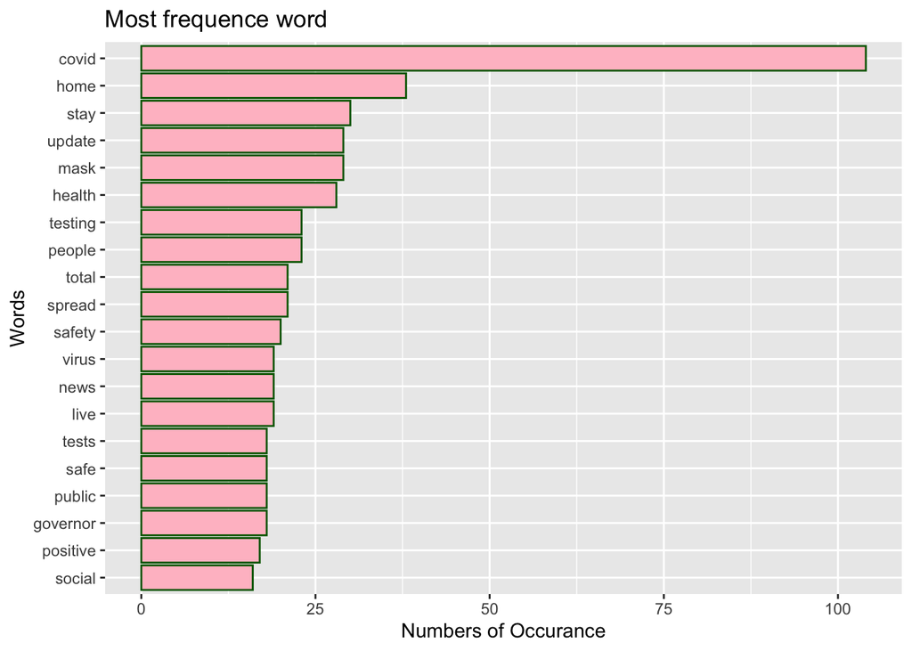

```r
datat_gov2 %>%
  filter(!str_detect(word, remove.list)) %>%
  filter(n > 15) %>%
  mutate(word = reorder(word, n)) %>%

  ggplot(aes(word, n)) +
  geom_col(color = "dark green", fill = "pink") +
  labs(title = "Most frequence word", x = "Words", y = "Numbers of Occurance") +
  coord_flip()
```

#Preprocess data ##Write a function to pre-process data

```r
library(tidyverse)
library(tm)
# Convert the 'tweet' column to character vector
data_gov$tweet <- as.character(data_gov$tweet)

# Define the preprocessing steps as a function
preprocess_data <- function(data) {
  # Remove short words
  data <- data %>%
    mutate(tweet = str_remove_all(tweet, "\\b\\w{1,2}\\b"))

  # Remove numbers
  data <- data %>%
    mutate(tweet = str_remove_all(tweet, "\\d+"))

  # Remove icons and special characters
  data <- data %>%
    mutate(tweet = str_remove_all(tweet, "[^[:alnum:]\\s]"))

  # Remove extra spaces
  data <- data %>%
    mutate(tweet = str_replace_all(tweet, "\\s+", " "))

  # Convert to lowercase
  data <- data %>%
    mutate(tweet = tolower(tweet))

  # Remove stopwords
  data <- data %>%
    mutate(tweet = removeWords(tweet, stopwords("english")))

  return(data)
}
```

# Apply the function to preprocess the data

```r
preprocessed_data_gov <- preprocess_data(data_gov)
preprocessed_data_gov
```

```
## # A tibble: 200 × 3
##         id username        tweet
##      <dbl> <chr>           <chr>
##  1 1.33e18 govlarryhogan   "covid  returned  state big way  must fight back  ev…
##  2 1.34e18 nygovcuomo      "delivering update  state covid response joined now …
##  3 1.25e18 govmlg          "stay home unless absolutely essential act    virus …
##  4 1.24e18 gavinnewsom     "families   lose  homes  covid  pleased  wells fargo…
##  5 1.3 e18 dougburgum      " highly skilled team  nddoh state lab dedicated pro…
##  6 1.3 e18 govevers        "wisconsin workers continue face financial burdens  …
##  7 1.28e18 governortomwolf " social distancing masking   safety measures must p…
##  8 1.24e18 govraimondo     "students please take  seriously  need keep   assign…
##  9 1.3 e18 govmikedewine   " reopening requirements include limited capacity li…
## 10 1.29e18 governortomwolf " want talk   transphobic incident involving  blooms…
## # ℹ 190 more rows
```

#create bigrams

```r
data_gov_bigram <- preprocessed_data_gov %>%
  unnest_tokens(bigram, tweet, token = "ngrams", n = 2) %>%
  count(bigram, sort = TRUE) %>%
  separate(bigram, c("word1", "word2"), sep = " ") %>%
  unite(bigram, word1, word2, sep = " ")
data_gov_bigram
```

```
## # A tibble: 3,273 × 2
##    bigram                n
##    <chr>             <int>
##  1 stay home            17
##  2 covid update         13
##  3 covid cases          11
##  4 social distancing    11
##  5 slow spread           9
##  6 wear mask             9
##  7 wearing mask          8
##  8 spread covid          7
##  9 back positive         6
## 10 came back             6
## # ℹ 3,263 more rows
```

#create trigrams

```r
data_gov_trigram <- preprocessed_data_gov %>%
  unnest_tokens(trigram, tweet, token = "ngrams", n = 3) %>%
  count(trigram, sort = TRUE) %>%
  separate(trigram, c("word1", "word2", "word3"), sep = " ") %>%
  unite(bigram, word1, word2, word3, sep = " ")
data_gov_trigram
```

```
## # A tibble: 3,393 × 2
##    bigram                           n
##    <chr>                        <int>
##  1 came back positive               6
##  2 today update numbers             6
##  3 covid fatalities yesterday       5
##  4 live governor hutchinson         5
##  5 positive total total             5
##  6 sadly covid fatalities           5
##  7 total total hospitalizations     5
##  8 update numbers tests             5
##  9 back positive total              4
## 10 new covid cases                  4
## # ℹ 3,383 more rows
```